# TrabajoEvaluacion

**Matriz de Covarianza**

Usando la función definida en las practicas obtenemos la matriz de covarianza

```r
mcov(datos_vino)
```

```
##                      fixed.acidity volatile.acidity   citric.acid
## fixed.acidity         0.7119681971    -1.930176e-03  2.952648e-02
## volatile.acidity     -0.0019301764     1.015747e-02 -1.822905e-03
## citric.acid           0.0295264821    -1.822905e-03  1.464280e-02
## residual.sugar        0.3809440223     3.285862e-02  5.781712e-02
## chlorides             0.0004255386     1.552458e-04  3.023221e-04
## free.sulfur.dioxide  -0.7087739060    -1.662665e-01  1.935902e-01
## total.sulfur.dioxide  3.2653465871     3.822758e-01  6.228615e-01
## density               0.0006695405     8.172264e-06  5.410275e-05
## pH                   -0.0542537470    -4.856539e-04 -2.991734e-03
## sulphates            -0.0016506552    -4.109063e-04  8.607072e-04
## alcohol              -0.1255071925     8.398008e-03 -1.127594e-02
## quality              -0.0849299662    -1.737889e-02 -9.868271e-04
##                      residual.sugar     chlorides free.sulfur.dioxide
## fixed.acidity           0.380944022  4.255386e-04        -0.708773906
## volatile.acidity        0.032858624  1.552458e-04        -0.166266506
## citric.acid             0.057817120  3.023221e-04         0.193590244
## residual.sugar         25.720517863  9.825496e-03        25.795310325
## chlorides               0.009825496  4.772363e-04         0.037666806
## free.sulfur.dioxide    25.795310325  3.766681e-02       289.183666769
## total.sulfur.dioxide   86.513636310  1.846498e-01       444.775064918
## density                 0.012724567  1.680410e-05         0.014962476
## pH                     -0.148653305 -2.983039e-04        -0.001586231
## sulphates              -0.015431592  4.178834e-05         0.114914468
## alcohol                -2.812166069 -9.682258e-03        -5.233439970
## quality                -0.438226605 -4.061276e-03         0.122853162
##                      total.sulfur.dioxide       density            pH
## fixed.acidity                  3.26534659  6.695405e-04 -5.425375e-02
## volatile.acidity               0.38227584  8.172264e-06 -4.856539e-04
## citric.acid                    0.62286152  5.410275e-05 -2.991734e-03
## residual.sugar                86.51363631  1.272457e-02 -1.486533e-01
## chlorides                      0.18464978  1.680410e-05 -2.983039e-04
## free.sulfur.dioxide          444.77506492  1.496248e-02 -1.586231e-03
## total.sulfur.dioxide        1805.71675147  6.733827e-02  1.489118e-02
## density                        0.06733827  8.943698e-06 -4.225998e-05
## pH                             0.01489118 -4.225998e-05  2.279653e-02
## sulphates                      0.65251133  2.542228e-05  2.686974e-03
## alcohol                      -23.47181150 -2.870844e-03  2.256045e-02
## quality                       -6.57540361 -8.133613e-04  1.329389e-02
##                          sulphates       alcohol       quality
## fixed.acidity        -1.650655e-03  -0.125507193 -0.0849299662
## volatile.acidity     -4.109063e-04   0.008398008 -0.0173788916
## citric.acid           8.607072e-04  -0.011275936 -0.0009868271
## residual.sugar       -1.543159e-02  -2.812166069 -0.4382266051
## chlorides             4.178834e-05  -0.009682258 -0.0040612763
## free.sulfur.dioxide   1.149145e-01  -5.233439970  0.1228531625
## total.sulfur.dioxide  6.525113e-01 -23.471811503 -6.5754036072
## density               2.542228e-05  -0.002870844 -0.0008133613
## pH                    2.686974e-03   0.022560445  0.0132938853
## sulphates             1.302205e-02  -0.002447856  0.0054243430
## alcohol              -2.447856e-03   1.514117789  0.4746294463
## quality               5.424343e-03   0.474629446  0.7841955475
```

De lo anterior podemos ver que:

1. `fixed.acidity` y `volatile.acidity`: La covarianza es negativa, lo que indica que tienden a moverse en direcciones opuestas. Cuando la acidez fija aumenta, la acidez volátil tiende a disminuir, y viceversa.
2. `fixed.acidity` y `citric.acid`: La covarianza es positiva, lo que indica que tienden a moverse juntas. Cuando la acidez fija aumenta, el ácido cítrico también tiende a aumentar.
3. `fixed.acidity` y `residual.sugar`: La covarianza es positiva, lo que indica que tienden a moverse juntas. Cuando la acidez fija aumenta, el azúcar residual también tiende a aumentar.
4. `volatile.acidity` y `residual.sugar`: La covarianza es positiva, lo que indica que tienden a moverse juntas. Cuando la acidez volátil aumenta, el azúcar residual también tiende a aumentar.
5. `citric.acid` y `residual.sugar`: La covarianza es positiva, lo que indica que tienden a moverse juntas. Cuando el ácido cítrico aumenta, el azúcar residual también tiende a aumentar.

**Matriz de correlaciones**

```r
cor(datos_vino)
```

```
##                      fixed.acidity volatile.acidity  citric.acid residual.sugar
## fixed.acidity           1.00000000      -0.02269729  0.289180698     0.08902070
## volatile.acidity       -0.02269729       1.00000000 -0.149471811     0.06428606
## citric.acid             0.28918070      -0.14947181  1.000000000     0.09421162
## residual.sugar          0.08902070       0.06428606  0.094211624     1.00000000
## chlorides               0.02308564       0.07051157  0.114364448     0.08868454
## free.sulfur.dioxide    -0.04939586      -0.09701194  0.094077221     0.29909835
## total.sulfur.dioxide    0.09106976       0.08926050  0.121130798     0.40143931
## density                 0.26533101       0.02711385  0.149502571     0.83896645
## pH                     -0.42585829      -0.03191537 -0.163748211    -0.19413345
## sulphates              -0.01714299      -0.03572815  0.062330940    -0.02666437
## alcohol                -0.12088112       0.06771794 -0.075728730    -0.45063122
## quality                -0.11366283      -0.19472297 -0.009209091    -0.09757683
##                        chlorides free.sulfur.dioxide total.sulfur.dioxide
## fixed.acidity         0.02308564       -0.0493958591          0.091069756
## volatile.acidity      0.07051157       -0.0970119393          0.089260504
## citric.acid           0.11436445        0.0940772210          0.121130798
## residual.sugar        0.08868454        0.2990983537          0.401439311
## chlorides             1.00000000        0.1013923521          0.198910300
## free.sulfur.dioxide   0.10139235        1.0000000000          0.615500965
## total.sulfur.dioxide  0.19891030        0.6155009650          1.000000000
## density               0.25721132        0.2942104109          0.529881324
## pH                   -0.09043946       -0.0006177961          0.002320972
## sulphates             0.01676288        0.0592172458          0.134562367
## alcohol              -0.36018871       -0.2501039415         -0.448892102
## quality              -0.20993441        0.0081580671         -0.174737218
##                          density            pH   sulphates     alcohol
## fixed.acidity         0.26533101 -0.4258582910 -0.01714299 -0.12088112
## volatile.acidity      0.02711385 -0.0319153683 -0.03572815  0.06771794
## citric.acid           0.14950257 -0.1637482114  0.06233094 -0.07572873
## residual.sugar        0.83896645 -0.1941334540 -0.02666437 -0.45063122
## chlorides             0.25721132 -0.0904394560  0.01676288 -0.36018871
## free.sulfur.dioxide   0.29421041 -0.0006177961  0.05921725 -0.25010394
## total.sulfur.dioxide  0.52988132  0.0023209718  0.13456237 -0.44889210
## density               1.00000000 -0.0935914935  0.07449315 -0.78013762
## pH                   -0.09359149  1.0000000000  0.15595150  0.12143210
## sulphates             0.07449315  0.1559514973  1.00000000 -0.01743277
## alcohol              -0.78013762  0.1214320987 -0.01743277  1.00000000
## quality              -0.30712331  0.0994272457  0.05367788  0.43557472
##                           quality
## fixed.acidity        -0.113662831
## volatile.acidity     -0.194722969
## citric.acid          -0.009209091
## residual.sugar       -0.097576829
## chlorides            -0.209934411
## free.sulfur.dioxide   0.008158067
## total.sulfur.dioxide -0.174737218
## density              -0.307123313
## pH                    0.099427246
## sulphates             0.053677877
## alcohol               0.435574715
## quality               1.000000000
```

De lo anterior podemos decir que:

1. `fixed.acidity` y `density`: Tienen una correlación positiva de 0.27, lo que indica una relación moderada. A medida que la acidez fija aumenta, la densidad también tiende a aumentar.
2. `volatile.acidity` y `quality`: Tienen una correlación negativa de -0.19, lo que indica una relación débil. A medida que la acidez volátil aumenta, la calidad tiende a disminuir.
3. `residual.sugar` y `density`: Tienen una correlación positiva muy fuerte de 0.84, lo que indica que a medida que el azúcar residual aumenta, la densidad también tiende a aumentar.
4. `chlorides` y `quality`: Tienen una correlación negativa de -0.21, lo que indica una relación débil. A medida que los cloruros aumentan, la calidad tiende a disminuir.
5. `free.sulfur.dioxide` y `total.sulfur.dioxide`: Tienen una correlación positiva fuerte de 0.62, lo que indica que a medida que el dióxido de azufre libre aumenta, el dióxido de azufre total también tiende a aumentar.
6. `alcohol` y `density`: Tienen una correlación negativa muy fuerte de -0.78, lo que indica que a medida que el alcohol aumenta, la densidad tiende a disminuir.
7. `alcohol` y `quality`: Tienen una correlación positiva de 0.44, lo que indica una relación moderada. A medida que el alcohol aumenta, la calidad también tiende a aumentar.

### Visualización de nuestros datos

**Histograma de nuestros datos**

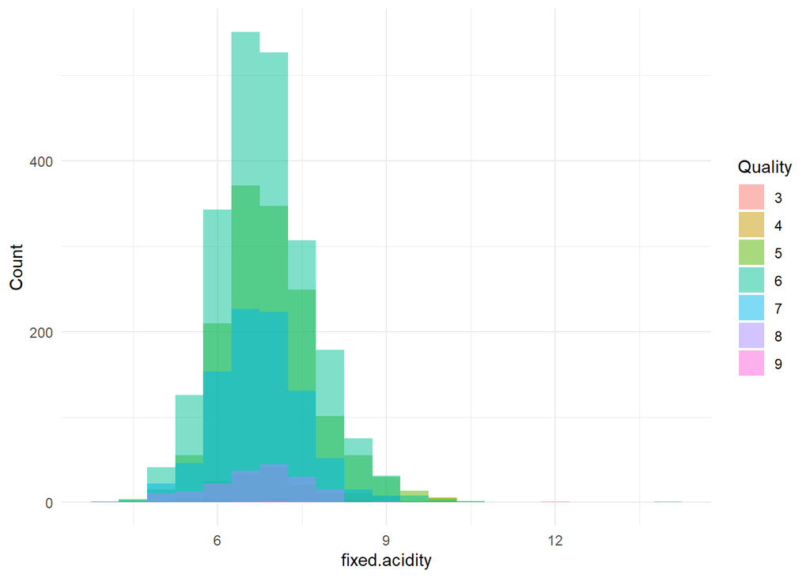

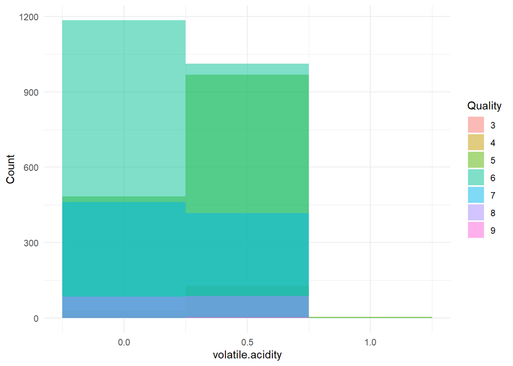

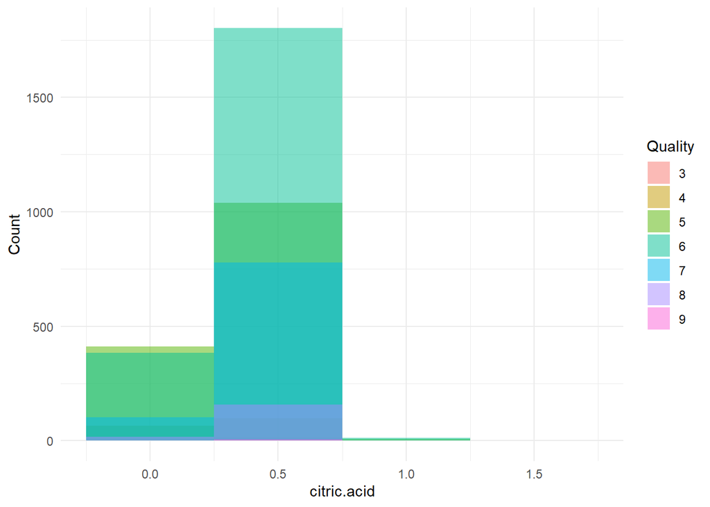

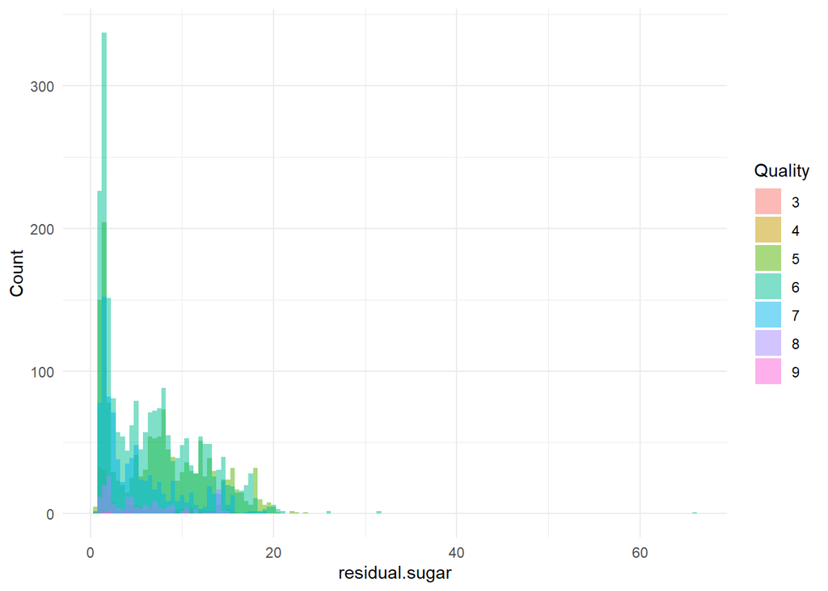

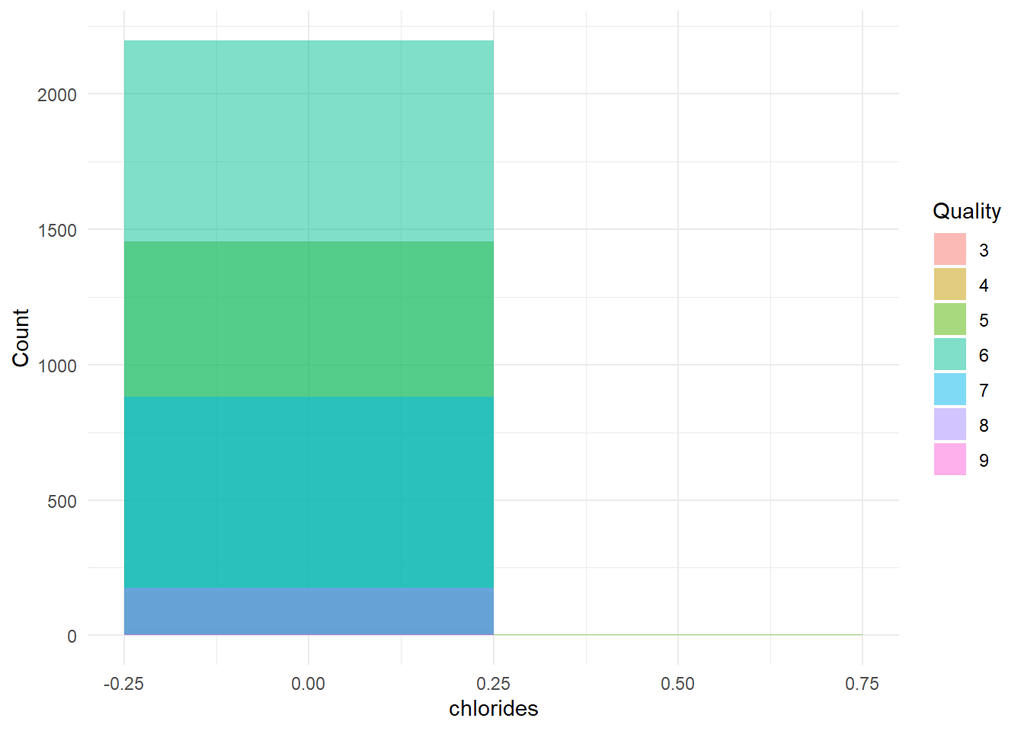

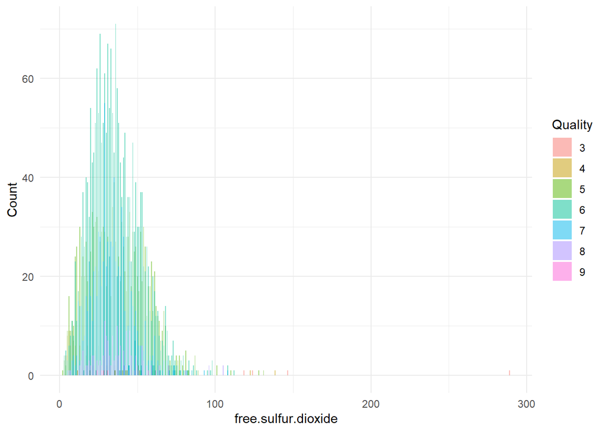

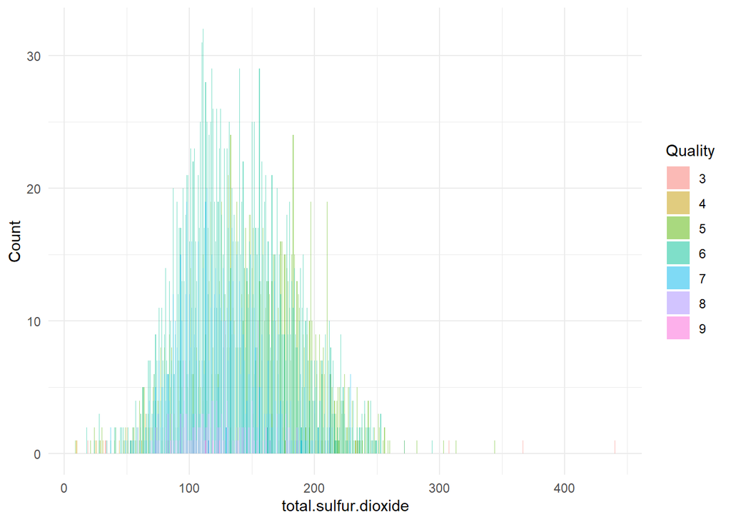

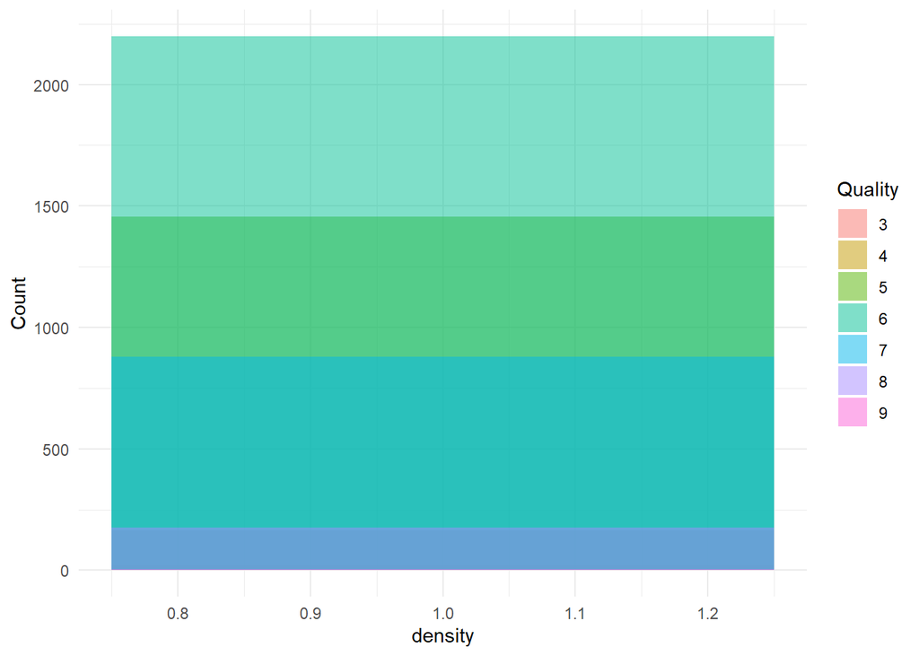

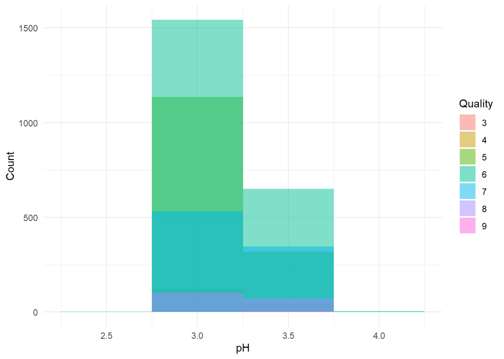

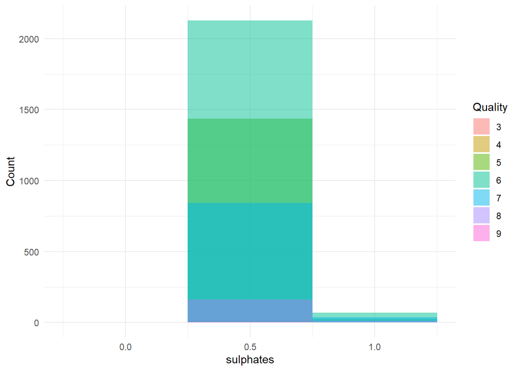

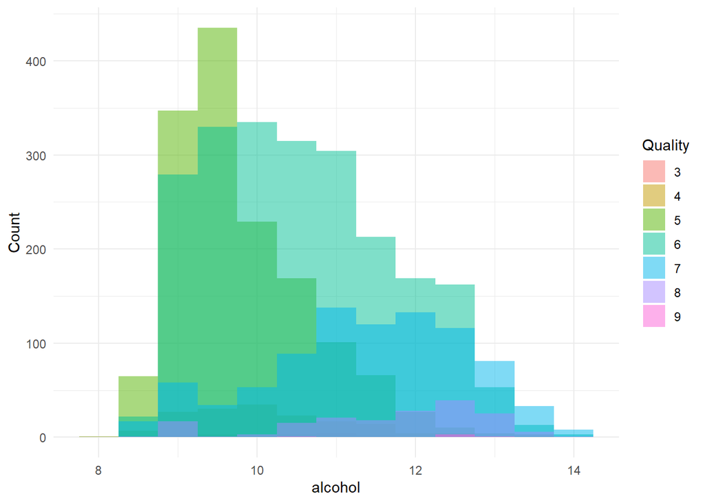

```r
library(ggplot2)
# Obtén los nombres de las columnas de tu conjunto de datos
columnas <- names(datos_vino)

datos_vino$quality <- factor(datos_vino$quality)

# Excluye la columna 'quality' ya que es la que usaremos para el relleno
columnas <- columnas[columnas != "quality"]

# Crea un histograma para cada columna
for (columna in columnas) {
  p <- ggplot(datos_vino, aes_string(x = columna, fill = "quality")) +
    geom_histogram(binwidth = .5, position = "identity", alpha = 0.5) +
    labs(x = columna, y = "Count", fill = "Quality") +
    theme_minimal()

  # Imprime el gráfico en la consola
  print(p)

  # Guarda el gráfico en un archivo
  ggsave(paste0("../Figuras/histograma_", columna, ".png"), plot = p)
}
```

En el anterior apartado generamos cada una de las graficas de los histogramas de cada una de las variables de nuestro dataSet y las dividimos coloreadas por el tipo de calidad de los vinos.

Algo que se puede resaltar es que, la cantidad de alcohol en un vino tiene relación con la calificación en su calidad.

**Diagrama de bigotes**

```r
library(reshape2)
# Reorganiza los datos en formato largo
datos_largos <- melt(datos_vino)
```

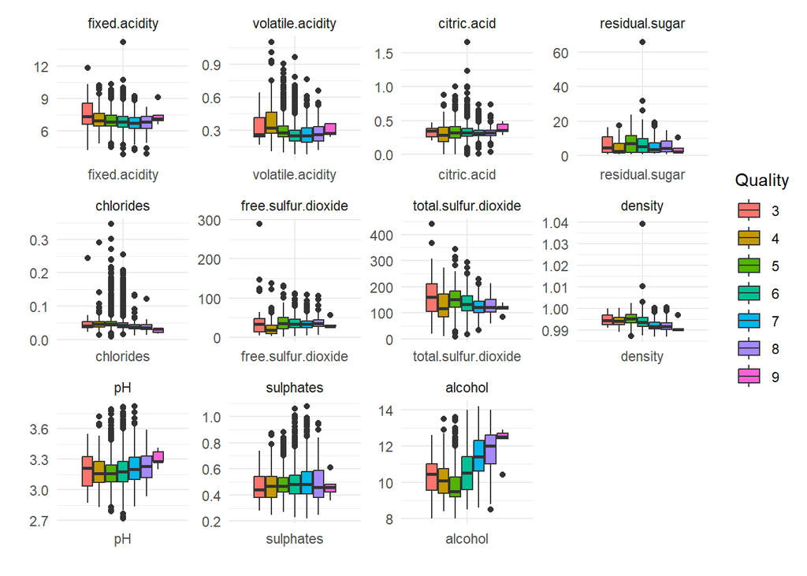

```r
# Crea el gráfico
p <- ggplot(datos_largos, aes(x = variable, y = value, fill = factor(quality))) +
  geom_boxplot() +
  facet_wrap(~ variable, scales = "free") +
  theme_minimal() +
  labs(x = "", y = "", fill = "Quality")

# Imprime el gráfico
print(p)
```

```r
# Guarda el gráfico en un archivo
ggsave("../Figuras/diagramas_bigotes_por_calidad.png", plot = p)
```

De los diagramas de bigotes anteriores podemos observar que, todas las variables poseen datos atipicos. Y que estos datos tienen en cada una de las calidades una cantidad amplia de las mismas.

**Grafico de dispersión**

```r
library(GGally)
```

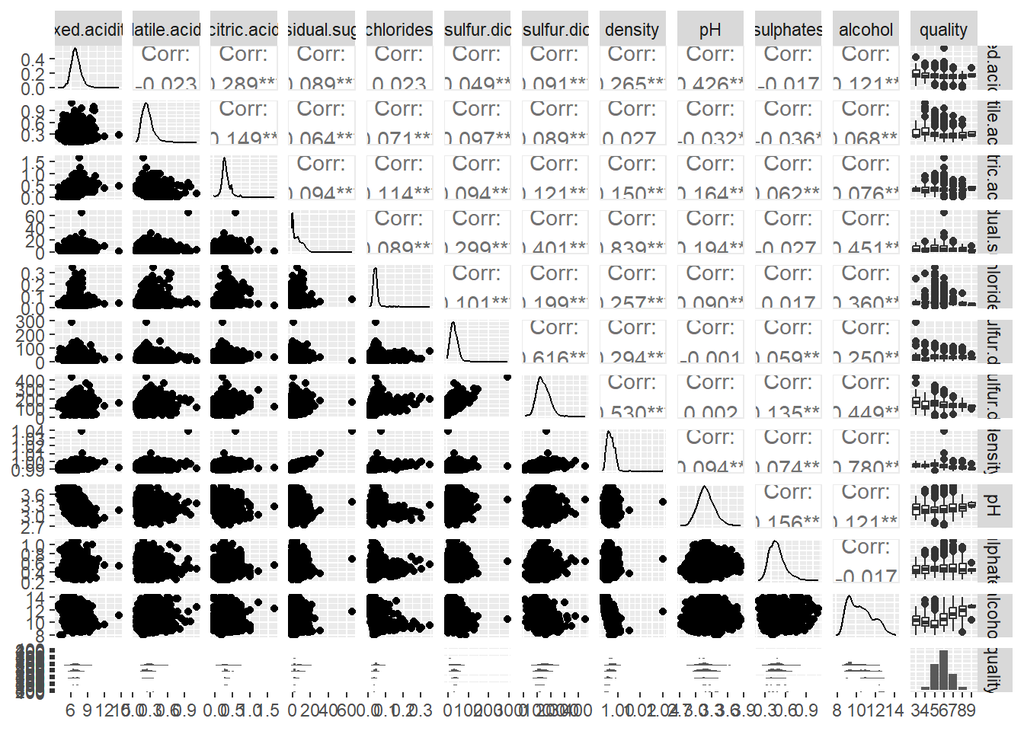

```r
# Crea el diagrama de dispersión
p <- ggpairs(datos_vino)

# Imprime el gráfico
print(p)
```

```r
# Guarda el gráfico en un archivo
ggsave("../Figuras/diagrama_dispersion.png", plot = p, width = 20, height = 20)
```